# CS 108 Statistics — Project 1

# 6: Relationships Between Numerical Variables

## 6.1 Distance from Star (pl_orbsmax) vs. Orbital Period (pl_orbper)

- **Direction and Strength**: There is a strong positive relationship between a planet’s semi-major axis and its orbital period. In general, planets with larger semi-major axes tend to have longer orbital periods. The Pearson correlation coefficient indicates a strong positive association between the two variables.
- **Form and Outliers**: On the logarithmic scales, the scatterplot shows a clear positive and approximately linear pattern.This indicates that the relationship is well described by a power-law-type pattern on the log-log scale. A small number of observations appear far from the main concentration of points, particularly at very large semi-major axes.

```r
# Semi-Major Axis vs. Orbital Period

# Filter out missing values, i.e complete-case analysis for this pair.
pair1 <- exo_clean %>%
  filter(!is.na(pl_orbsmax) & !is.na(pl_orbper))

# Calculate Pearson Correlation
cor_pair1 <- cor(pair1$pl_orbsmax, pair1$pl_orbper, method = "pearson")
cat("Correlation between Distance and Period:", round(cor_pair1, 2), "\n")
```

```
## Correlation between Distance and Period: 0.69
```

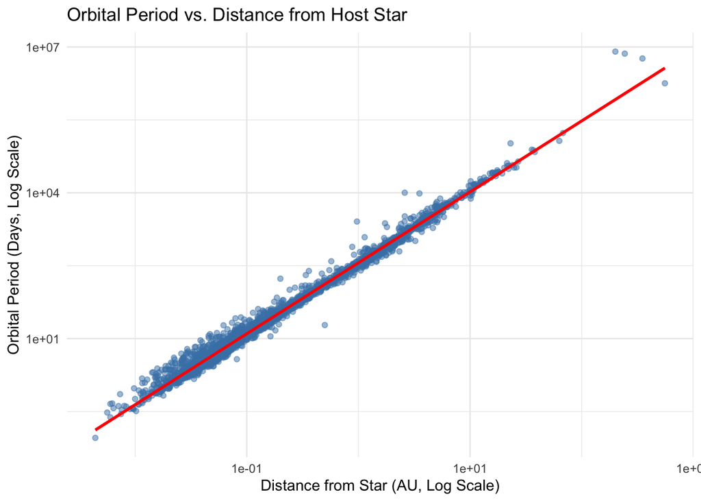

```r
# Simple Scatterplot
ggplot(pair1, aes(x = pl_orbsmax, y = pl_orbper)) +
  geom_point(alpha = 0.5, color = "steelblue") +
  scale_x_log10() +
  scale_y_log10() +
  geom_smooth(method = "lm", color = "red", se = FALSE) +
  labs(
    title = "Orbital Period vs. Distance from Host Star",
    x = "Distance from Star (AU, Log Scale)",
    y = "Orbital Period (Days, Log Scale)"
  ) +
  theme_minimal()
```

## 6.2 Planet Mass (pl_bmasse) vs. Planet Radius (pl_rade)

- **Direction and Strength**: There is a positive relationship between planet mass and planet radius. In general, planets with larger masses tend to have larger radii, although the points show considerable variation around the overall trend.
- **Form and Outliers**: On the log-log scale, the scatterplot shows an overall upward trend, but the relationship is not perfectly linear. The spread of the observations changes across the range of mass and radius, and several observations appear separated from the main pattern. These observations can be considered potential outliers and should be investigated rather than automatically removed.

```r
# Filter out missing values
pair2 <- exo_clean %>%
  filter(!is.na(pl_bmasse) & !is.na(pl_rade))

# Calculate Pearson Correlation
cor_pair2 <- cor(pair2$pl_bmasse, pair2$pl_rade, method = "pearson")
cat("Correlation between Mass and Radius:", round(cor_pair2, 2), "\n")
```

```
## Correlation between Mass and Radius: 0.36
```

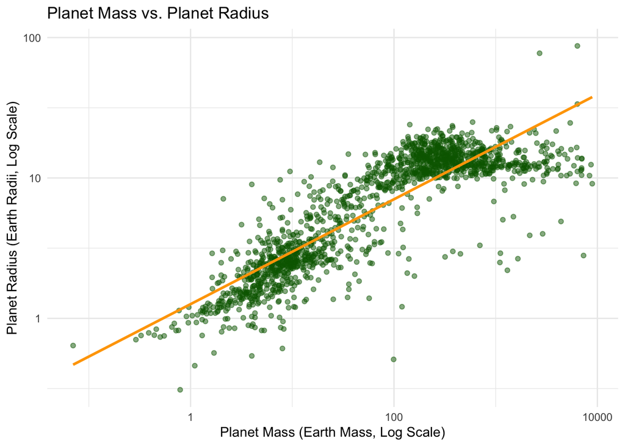

```r
# Simple Scatterplot
ggplot(pair2, aes(x = pl_bmasse, y = pl_rade)) +
  geom_point(alpha = 0.5, color = "darkgreen") +
  scale_x_log10() +
  scale_y_log10() +
  geom_smooth(method = "lm", color = "orange", se = FALSE) +
  labs(
    title = "Planet Mass vs. Planet Radius",
    x = "Planet Mass (Earth Mass, Log Scale)",
    y = "Planet Radius (Earth Radii, Log Scale)"
  ) +
  theme_minimal()
```

## 6.3 Planet Mass vs. Planet Radius by Discovery Method

To investigate whether the discovery method changes the relationship between planet mass and radius, the relationship from Section 6.2 was compared across the main discovery-method groups.

The scatterplot shows a positive relationship between mass and radius across the discovery methods. However, the groups are distributed differently across the plot, with some methods concentrated in particular ranges of mass and radius. The fitted lines allow the overall relationship to be compared between the groups.

Overall, the positive relationship between mass and radius remains visible across the discovery methods, but the distribution and spread of the observations differ between groups. This suggests that discovery method is associated with differences in the observed mass-radius relationship, although this analysis does not establish a causal effect.

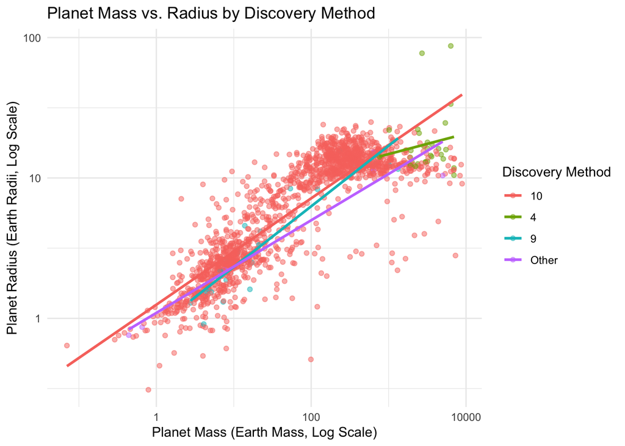

```r
## 6.3 Planet Mass vs. Planet Radius by Discovery Method

pair3 <- exo_clean %>%
  filter(
    !is.na(pl_bmasse),
    !is.na(pl_rade),
    !is.na(disc_method_cat)
  )

ggplot(pair3,
       aes(x = pl_bmasse,
           y = pl_rade,
           color = disc_method_cat)) +
  geom_point(alpha = 0.5) +
  scale_x_log10() +
  scale_y_log10() +
  geom_smooth(method = "lm", se = FALSE) +
  labs(
    title = "Planet Mass vs. Radius by Discovery Method",
    x = "Planet Mass (Earth Mass, Log Scale)",
    y = "Planet Radius (Earth Radii, Log Scale)",
    color = "Discovery Method"
  ) +
  theme_minimal()
```

# 7. Distributional Analysis and QQ Plots

We study **planet equilibrium temperature (`pl_eqt`)**, measured in Kelvin.

Our questions are:

1. Can equilibrium temperature be reasonably described by a Normal distribution?
2. Does its distribution change by discovery method?

## 7.1 Overall Distribution

First, we remove missing values.

```r
eqt <- exo_clean$pl_eqt[!is.na(exo_clean$pl_eqt)]

length(eqt)
```

```
## [1] 1753
```

We calculate the main descriptive statistics.

```r
eqt_mean <- mean(eqt)
eqt_median <- median(eqt)
eqt_min <- min(eqt)
eqt_max <- max(eqt)
eqt_range <- eqt_max - eqt_min
eqt_q1 <- quantile(eqt, 0.25)
eqt_q3 <- quantile(eqt, 0.75)
eqt_iqr <- IQR(eqt)
eqt_sd <- sd(eqt)



cat("Number of observations:", length(eqt), "\n")
```

```
## Number of observations: 1753
```

```r
cat("Mean:", round(eqt_mean, 2), "K\n")
```

```
## Mean: 1001.02 K
```

```r
cat("Median:", round(eqt_median, 2), "K\n")
```

```
## Median: 900 K
```

```r
cat("Minimum:", eqt_min, "K\n")
```

```
## Minimum: 50 K
```

```r
cat("Maximum:", eqt_max, "K\n")
```

```
## Maximum: 3921 K
```

```r
cat("Range:", round(eqt_range, 2), "K\n")
```

```
## Range: 3871 K
```

```r
cat("Q1:", round(eqt_q1, 2), "K\n")
```

```
## Q1: 573 K
```

```r
cat("Q3:", round(eqt_q3, 2), "K\n")
```

```
## Q3: 1373 K
```

```r
cat("IQR:", round(eqt_iqr, 2), "K\n")
```

```
## IQR: 800 K
```

```r
cat("Standard deviation:", round(eqt_sd, 2), "K\n")
```

```
## Standard deviation: 539.97 K
```

### Histogram

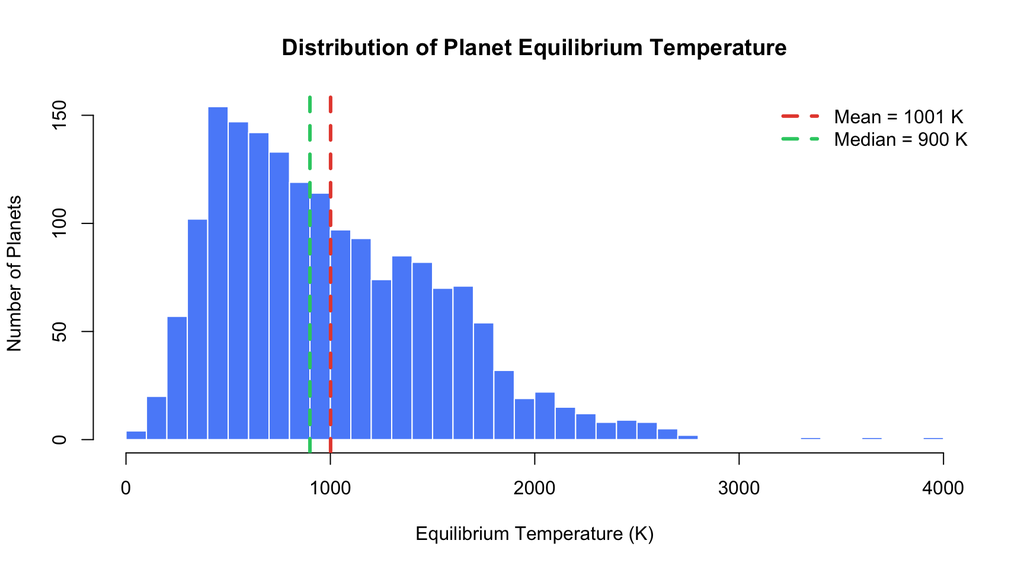

```r
hist(
  eqt,
  breaks = 40,
  col = "#5B8FF9",
  border = "white",
  main = "Distribution of Planet Equilibrium Temperature",
  xlab = "Equilibrium Temperature (K)",
  ylab = "Number of Planets"
)

abline(
  v = eqt_mean,
  col = "#E74C3C",
  lwd = 3,
  lty = 2
)

abline(
  v = eqt_median,
  col = "#2ECC71",
  lwd = 3,
  lty = 2
)

legend(
  "topright",
  legend = c(
    paste("Mean =", round(eqt_mean, 1), "K"),
    paste("Median =", round(eqt_median, 1), "K")
  ),
  col = c("#E74C3C", "#2ECC71"),
  lty = 2,
  lwd = 3,
  bty = "n"
)
```

The histogram has a long upper tail, so the distribution is strongly right-skewed.

## 7.2 Normal Distribution and QQ Plot

We use the Normal distribution as a theoretical reference to see whether it is a reasonable description of the data.

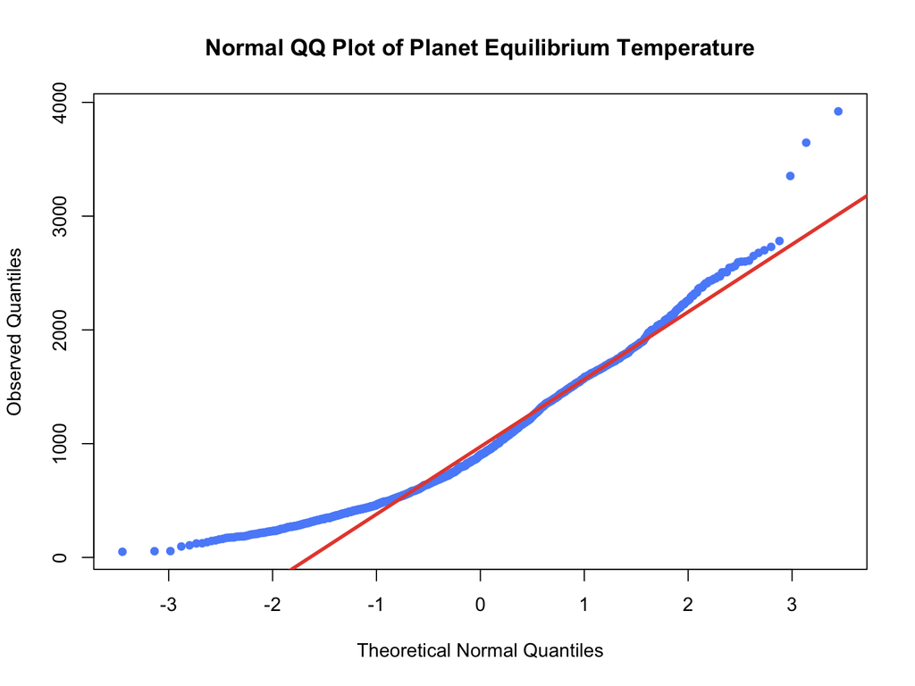

```r
qqnorm(
  eqt,
  main = "Normal QQ Plot of Planet Equilibrium Temperature",
  xlab = "Theoretical Normal Quantiles",
  ylab = "Observed Quantiles",
  pch = 16,
  col = "#5B8FF9"
)

qqline(
  eqt,
  col = "#E74C3C",
  lwd = 3
)
```

The points are closer to the line in the middle but deviate systematically in the tails, especially the upper tail.

Therefore, equilibrium temperature is **not reasonably described by a Normal distribution**.

The extreme upper observations are potentially unusual, but we do not automatically consider them errors.

## 7.3 Distribution by Discovery Method

We compare:

- Transit
- Radial Velocity
- Imaging

```r
transit <- exo_clean$pl_eqt[
  exo_clean$discoverymethod == "Transit" &
    !is.na(exo_clean$pl_eqt)
]

rv <- exo_clean$pl_eqt[
  exo_clean$discoverymethod == "Radial Velocity" &
    !is.na(exo_clean$pl_eqt)
]

imaging <- exo_clean$pl_eqt[
  exo_clean$discoverymethod == "Imaging" &
    !is.na(exo_clean$pl_eqt)
]

cat("Transit:", length(transit), "\n")
```

```
## Transit: 1536
```

```r
cat("Radial Velocity:", length(rv), "\n")
```

```
## Radial Velocity: 152
```

```r
cat("Imaging:", length(imaging), "\n")
```

```
## Imaging: 52
```

### Boxplot

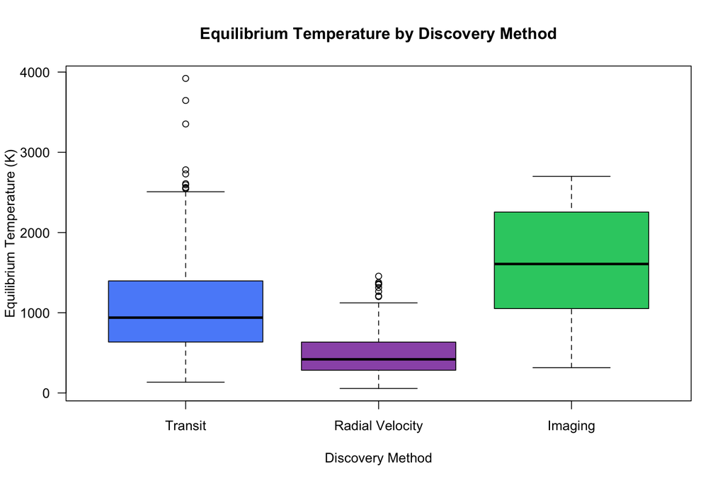

```r
boxplot(
  transit,
  rv,
  imaging,
  names = c("Transit", "Radial Velocity", "Imaging"),
  col = c("#5B8FF9", "#9B59B6", "#2ECC71"),
  border = "black",
  main = "Equilibrium Temperature by Discovery Method",
  xlab = "Discovery Method",
  ylab = "Equilibrium Temperature (K)",
  las = 1
)
```

Imaging has the highest center and the largest spread.

Transit and Radial Velocity have lower centers and more right-skewed distributions.

### Numerical Summary

```r
transit_mean <- mean(transit)
transit_median <- median(transit)
transit_sd <- sd(transit)
transit_iqr <- IQR(transit)



rv_mean <- mean(rv)
rv_median <- median(rv)
rv_sd <- sd(rv)
rv_iqr <- IQR(rv)



imaging_mean <- mean(imaging)
imaging_median <- median(imaging)
imaging_sd <- sd(imaging)
imaging_iqr <- IQR(imaging)



group_summary <- data.frame(
  Method = c(
    "Transit",
    "Radial Velocity",
    "Imaging"
  ),
  Count = c(
    length(transit),
    length(rv),
    length(imaging)
  ),
  Mean = c(
    transit_mean,
    rv_mean,
    imaging_mean
  ),
  Median = c(
    transit_median,
    rv_median,
    imaging_median
  ),
  SD = c(
    transit_sd,
    rv_sd,
    imaging_sd
  ),
  IQR = c(
    transit_iqr,
    rv_iqr,
    imaging_iqr
  )
)

knitr::kable(
  group_summary,
  digits = 2,
  caption = "Equilibrium Temperature by Discovery Method"
)
```

Equilibrium Temperature by Discovery Method

| Method | Count | Mean | Median | SD | IQR |
| --- | --- | --- | --- | --- | --- |
| Transit | 1536 | 1034.25 | 939.15 | 514.23 | 762.00 |
| Radial Velocity | 152 | 512.55 | 419.50 | 313.71 | 346.75 |
| Imaging | 52 | 1575.42 | 1608.00 | 743.91 | 1194.50 |

Imaging has the highest median and largest IQR.

## 7.4 QQ Plots by Discovery Method

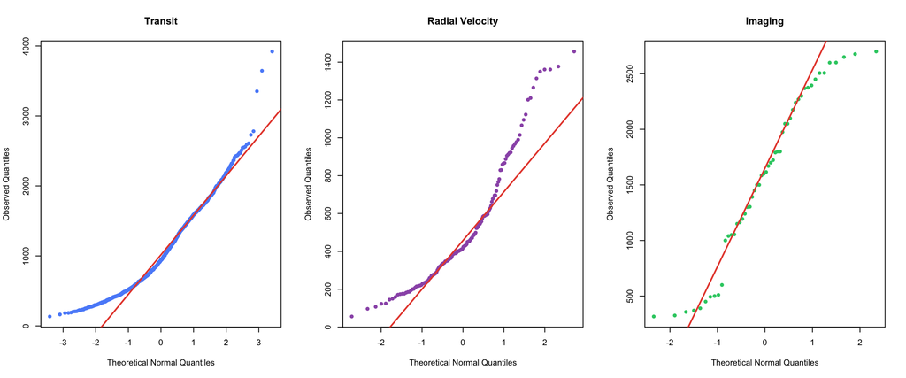

```r
par(mfrow = c(1, 3))

qqnorm(
  transit,
  main = "Transit",
  xlab = "Theoretical Normal Quantiles",
  ylab = "Observed Quantiles",
  pch = 16,
  col = "#5B8FF9"
)

qqline(
  transit,
  col = "#E74C3C",
  lwd = 2
)

qqnorm(
  rv,
  main = "Radial Velocity",
  xlab = "Theoretical Normal Quantiles",
  ylab = "Observed Quantiles",
  pch = 16,
  col = "#9B59B6"
)

qqline(
  rv,
  col = "#E74C3C",
  lwd = 2
)

qqnorm(
  imaging,
  main = "Imaging",
  xlab = "Theoretical Normal Quantiles",
  ylab = "Observed Quantiles",
  pch = 16,
  col = "#2ECC71"
)

qqline(
  imaging,
  col = "#E74C3C",
  lwd = 2
)
```

```r
par(mfrow = c(1, 1))
```

Transit and Radial Velocity show stronger curvature and right-skewness.

Imaging is appears more symmetric and closer to a linear pattern in the middle, but its sample size is much smaller.

## 7.5 Final Conclusion

The three discovery methods have clearly different equilibrium-temperature distributions.

- **Location:** Imaging has the highest median.
- **Spread:** Imaging has the largest IQR.
- **Skewness:** Transit and Radial Velocity are right-skewed.
- **Tails:** Transit has a particularly long upper tail.
- **Shape:** Imaging is more symmetric.

Overall, the differences are substantial rather than minor.

The results show an association between discovery method and equilibrium temperature, but they do not show that discovery method causes the differences.

# 8. Integrated Exploratory Data Analysis

- the planet radius distribution is bimodal (small planets and gas giants);
- the discovery-method mix changes strongly over time (Section 3.5);
- orbital distance and period are strongly related (Section 6.1).

```r
# Rebuild helper variables so that this section does not depend on earlier edits
exo8 <- exo_clean %>%
  mutate(
    discoverymethod = as.character(discoverymethod),
    method_grp = ifelse(discoverymethod %in% c("Transit", "Radial Velocity",
                                               "Microlensing", "Imaging"),
                        discoverymethod, "Other"),
    disc_era = cut(disc_year,
                   breaks = c(-Inf, 2009, 2014, 2019, Inf),
                   labels = c("Before 2010", "2010-2014", "2015-2019", "2020 onward")),
    # Planet size classes (Earth radii)
    size_class = cut(pl_rade,
                     breaks = c(0, 2, 6, Inf),
                     labels = c("Small (<2)", "Mid-size (2-6)", "Giant (>=6)"),
                     right = FALSE)
  )
```

### 8.1 Question 1: Has the typical size of newly discovered planets changed over time, and is this a real change or a detection effect?

**Variables:** planet radius (`pl_rade`), discovery period (`disc_era`), size class, and discovery method (`discoverymethod`) as a check.

**Methods:** grouped summaries by era, share of each size class by era, boxplots on the log scale, and a repeat of the analysis using only Transit discoveries to see whether a change in method explains the pattern.

```r
q1 <- exo8 %>% filter(!is.na(pl_rade), !is.na(disc_era))

q1_summary <- q1 %>%
  group_by(disc_era) %>%
  summarise(
    n         = n(),
    Median    = median(pl_rade),
    Q1        = quantile(pl_rade, 0.25),
    Q3        = quantile(pl_rade, 0.75),
    IQR       = IQR(pl_rade),
    Pct_Small = 100 * mean(size_class == "Small (<2)"),
    Pct_Mid   = 100 * mean(size_class == "Mid-size (2-6)"),
    Pct_Giant = 100 * mean(size_class == "Giant (>=6)")
  )
knitr::kable(q1_summary, digits = 2,
             caption = "Planet radius (Earth radii) by discovery period")
```

Planet radius (Earth radii) by discovery period

| disc_era | n | Median | Q1 | Q3 | IQR | Pct_Small | Pct_Mid | Pct_Giant |
| --- | --- | --- | --- | --- | --- | --- | --- | --- |
| Before 2010 | 73 | 13.67 | 12.25 | 15.61 | 3.36 | 2.74 | 4.11 | 93.15 |
| 2010-2014 | 1111 | 2.35 | 1.58 | 3.55 | 1.97 | 38.43 | 43.47 | 18.09 |
| 2015-2019 | 1977 | 2.26 | 1.54 | 3.23 | 1.69 | 41.12 | 42.79 | 16.08 |
| 2020 onward | 1580 | 2.76 | 1.92 | 7.25 | 5.33 | 26.65 | 46.52 | 26.84 |

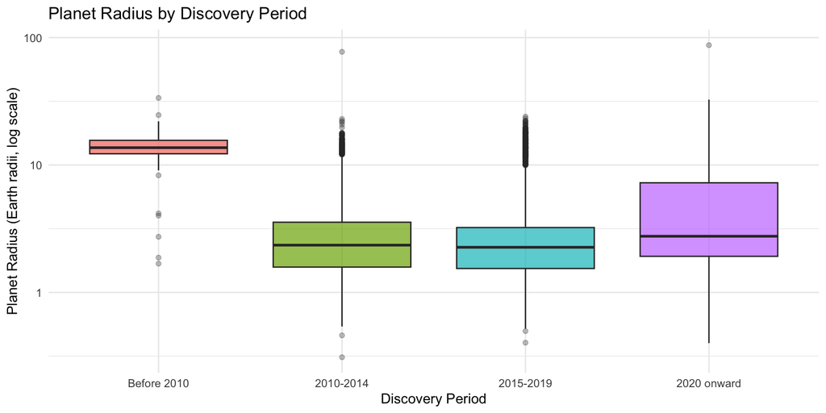

```r
# (a) Boxplot of radius by era (log scale)
ggplot(q1, aes(x = disc_era, y = pl_rade, fill = disc_era)) +
  geom_boxplot(alpha = 0.7, outlier.alpha = 0.3, show.legend = FALSE) +
  scale_y_log10() +
  labs(title = "Planet Radius by Discovery Period",
       x = "Discovery Period", y = "Planet Radius (Earth radii, log scale)") +
  theme_minimal()
```

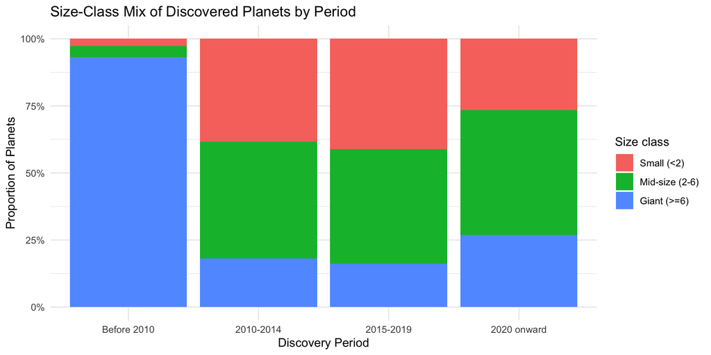

```r
# (b) Size-class mix by era
ggplot(q1, aes(x = disc_era, fill = size_class)) +
  geom_bar(position = "fill") +
  scale_y_continuous(labels = percent) +
  labs(title = "Size-Class Mix of Discovered Planets by Period",
       x = "Discovery Period", y = "Proportion of Planets", fill = "Size class") +
  theme_minimal()
```

```r
# Does the pattern survive when only one method (Transit) is used?
q1_transit <- q1 %>%
  filter(discoverymethod == "Transit") %>%
  group_by(disc_era) %>%
  summarise(n = n(),
            Median = median(pl_rade),
            Pct_Giant = 100 * mean(size_class == "Giant (>=6)"))
knitr::kable(q1_transit, digits = 2,
             caption = "Transit discoveries only: radius by period")
```

Transit discoveries only: radius by period

| disc_era | n | Median | Pct_Giant |
| --- | --- | --- | --- |
| Before 2010 | 57 | 14.01 | 94.74 |
| 2010-2014 | 1099 | 2.34 | 17.56 |
| 2015-2019 | 1964 | 2.26 | 15.89 |
| 2020 onward | 1555 | 2.76 | 26.50 |

```r
# Radial-velocity masses over time (sensitivity of the method)
exo8 %>%
  filter(discoverymethod == "Radial Velocity", !is.na(pl_bmasse), !is.na(disc_era)) %>%
  group_by(disc_era) %>%
  summarise(n = n(), Median_mass = median(pl_bmasse)) %>%
  knitr::kable(digits = 1,
               caption = "Radial Velocity discoveries: median planet mass (Earth masses)")
```

Radial Velocity discoveries: median planet mass (Earth masses)

| disc_era | n | Median_mass |
| --- | --- | --- |
| Before 2010 | 311 | 525.7 |
| 2010-2014 | 206 | 349.6 |
| 2015-2019 | 255 | 212.9 |
| 2020 onward | 423 | 75.4 |

**What this tells us:** early surveys could only detect large, massive planets, and as instruments and surveys improved, much smaller planets became detectable. **What it does not tell us:** that the *population* of planets changed. The pre-2010 group is also small (n = 73 with radius), so its summaries are less stable, and the small rise after 2020 may reflect specific surveys targeting giant planets.

### 8.2 Question 2: Does the relationship between equilibrium temperature and orbital distance depend on the temperature of the host star?

**Variables:** equilibrium temperature (`pl_eqt`), semi-major axis (`pl_orbsmax`), and host star effective temperature (`st_teff`), split into three equal-sized groups (Cool, Medium, Hot).

```r
q3 <- exo8 %>%
  filter(!is.na(pl_eqt), !is.na(pl_orbsmax), !is.na(st_teff))

# Three equal-sized groups of host stars by effective temperature
cuts <- quantile(q3$st_teff, probs = c(0, 1/3, 2/3, 1))
q3 <- q3 %>%
  mutate(star_class = cut(st_teff, breaks = cuts, include.lowest = TRUE,
                          labels = c("Cool host", "Medium host", "Hot host")))
# counting the rows of q3 which includes the data where all key attributes for our analysis are present
nrow(q3)
```

```
## [1] 1542
```

```r
q3 %>%
  group_by(star_class) %>%
  summarise(n = n(),
            Teff_min = min(st_teff), Teff_max = max(st_teff),
            Median_eqt = median(pl_eqt),
            Median_smax = median(pl_orbsmax)) %>%
  knitr::kable(digits = 3, caption = "Host-star classes and planet summaries")
```

Host-star classes and planet summaries

| star_class | n | Teff_min | Teff_max | Median_eqt | Median_smax |
| --- | --- | --- | --- | --- | --- |
| Cool host | 514 | 415 | 4914 | 583.40 | 0.050 |
| Medium host | 515 | 4916 | 5735 | 952.09 | 0.068 |
| Hot host | 513 | 5737 | 10500 | 1431.00 | 0.061 |

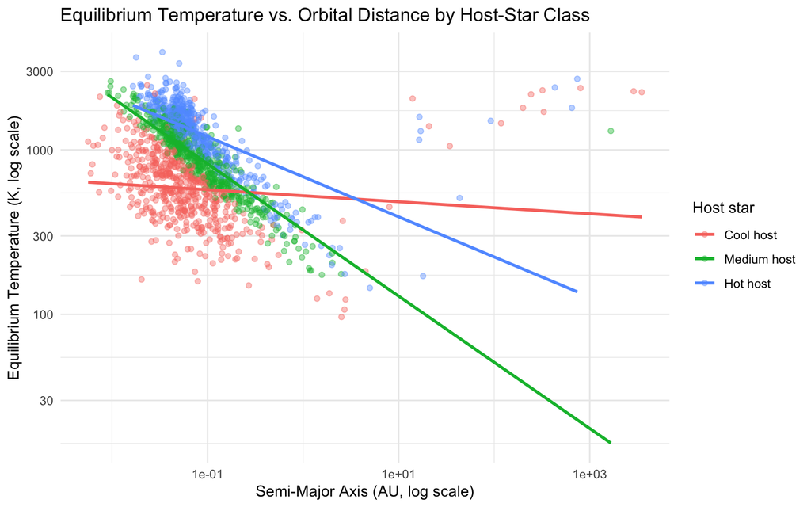

```r
ggplot(q3, aes(x = pl_orbsmax, y = pl_eqt, color = star_class)) +
  geom_point(alpha = 0.4) +
  geom_smooth(method = "lm", se = FALSE) +
  scale_x_log10() +
  scale_y_log10() +
  labs(title = "Equilibrium Temperature vs. Orbital Distance by Host-Star Class",
       x = "Semi-Major Axis (AU, log scale)",
       y = "Equilibrium Temperature (K, log scale)",
       color = "Host star") +
  theme_minimal()
```

```r
cat("Overall correlation (log-log) =", round(cor(log10(q3$pl_orbsmax), log10(q3$pl_eqt)), 2), "\n")
```

```
## Overall correlation (log-log) = -0.34
```

```r
q3 %>%
  group_by(star_class) %>%
  summarise(n = n(),
            r_log = cor(log10(pl_orbsmax), log10(pl_eqt))) %>%
  knitr::kable(digits = 2, caption = "Log-log correlation and slope by host-star class")
```

Log-log correlation and slope by host-star class

| star_class | n | r_log |
| --- | --- | --- |
| Cool host | 514 | -0.11 |
| Medium host | 515 | -0.84 |
| Hot host | 513 | -0.62 |

**Results and interpretation.** Equilibrium temperature tends to decrease with distance, but the strength depends on the host. Overall (n = 1,542) the log-log correlation is only -0.34. Within host groups, the relationship is strong for medium-temperature hosts (r = -0.84) and for hot hosts (r = -0.62), but almost absent for cool hosts (r = -0.11). The classes also differ in level: the median planet temperature is about 583 K around cool hosts, 952 K around medium hosts and 1,431 K around hot hosts, even though the median orbital distance is similar (0.05-0.07 AU) in all three. So, at a given distance, planets around hotter stars are hotter, and this is the main reason why the overall correlation is weak. Physical models predict a slope of about -0.5 in this log-log relation, and only the medium group is relatively close to this.

**What this tells us:** the host star must be taken into account when relating planet temperature to orbital distance. **What it does not tell us:** `pl_eqt` is not measured directly. It is *calculated* from the star’s temperature and radius and the orbital distance, so part of this relationship holds by construction. The sample is also limited to planets that have all three variables (1,542 of 6,366), mostly transiting planets close to their stars, so the cool-host result may reflect a narrow range of distances rather than a true absence of relationship.

# 10. Conclusions

In this project we analysed the NASA Exoplanet Archive, using one default parameter set per planet (6,366 planets). The main findings are below.

**1. Most important characteristics of the dataset.** The data are very unbalanced. Transit discovers 74% of planets and Radial Velocity 19%, 91% of planets orbit single stars, and 94% were discovered after 2010. Many measurements are missing (for example, 81% of planet masses), so each analysis uses a different number of planets. The numerical variables (radius, mass, period, distance) are strongly right-skewed and cover several orders of magnitude, so the median and IQR describe them better than the mean and SD. On the log scale, radius and mass are bimodal, which suggests two populations: small planets and gas giants.

**2. Patterns and associations.** The discovery method is associated with the stellar multiplicity (about 6% of Transit planets are in binary systems, against 16.5% for Imaging). The method mix also changed over time: Radial Velocity dominated before 2010, while Transit dominates afterwards. The size of the discovered planets changed as well: the median radius fell from about 13.7 Earth radii before 2010 to about 2.3-2.8 later. Giant planets are concentrated at short periods (about 76% of giants orbit in under 10 days).

**3. Differences between groups.** Planet radius differs a lot between methods (median about 15 Earth radii for Imaging against 2.5 for Transit). Orbital period is longer and much more spread out in binary and multi-star systems (IQR about 213-252 days against 31 days for single stars). Equilibrium temperature also differs (median about 1,608 K for Imaging, 939 K for Transit and 420 K for Radial Velocity).

**4. Relationships between variables.** Orbital distance and orbital period have a very strong relationship on the log scale (r = 0.995), and mass and radius are strongly related on the log scale (r = 0.86). A planet’s equilibrium temperature decreases with distance, but how strongly depends on the host star (r = -0.84 for medium-temperature hosts and r = -0.11 for cool hosts).

**5. Distributions across categories.** Yes, the distributions clearly change across categories. The equilibrium-temperature distributions differ in location, spread and skewness between the three methods, and the differences are substantial. Imaging is the highest and the most symmetric (but has few planets), while Transit and Radial Velocity are right-skewed.

**7. Surprising findings.** Three results surprised us. First, the raw correlations can be very misleading: mass and radius have r = 0.36 on the raw scale but r = 0.86 on the log scale, because of extreme values. Second, pooled results can hide subgroups: radius and period are almost uncorrelated overall (r = 0.04), but they have opposite trends for small planets (+0.28) and giants (-0.34). Third, the share of giant planets went up again after 2020, so the change in planet size over time was not a simple decrease.

**8. Limitations.** - The archive contains planets that we are *able to detect*, not a random sample of all planets, so many patterns (size over time, hot Jupiters, method differences) are mostly detection bias. - There are a lot of missing values, so the analysis uses available cases only, and the planets with all variables may not represent the rest. - Some groups are small (Imaging, Other, and Radial Velocity planets with radius), so their summaries are unstable. - Some masses are only minimum masses (Msini), and the most extreme orbital values are uncertain. - Equilibrium temperature is calculated from other variables, not measured directly, and the size classes (2 and 6 Earth radii) are arbitrary. - We kept all outliers because they are real objects, but they strongly affect means and standard deviations.

Finally, this is an exploratory analysis. It describes patterns and associations, but it does not establish causation.